# Evaluating the Impact of Orthogonal Correction on Simulated Group Discrimination

Tecla Duran Fort 2025-06-09

# 1. Introduction

This document evaluates the impact of an orthogonal projection correction applied in the sample space to GC-IMS peak table data. The analysis is based on a dataset where a controlled perturbation is introduced in a specific signal to simulate a potential biomarker shift.

We begin by applying this perturbation to a selected cluster and splitting the dataset into training and test sets using stratified sampling. A PLS-DA model is then trained on the raw data and evaluated through ROC curves and AUC values. The same procedure is repeated after correcting the data using a two-step orthogonal projection based on elapsed time and batch.

To better understand the model behaviour, we visualize the latent space projections (PLS-DA scores) before and after correction. Finally, this process is extended to multiple clusters and perturbation levels to assess the consistency of the correction effect, and summary statistics are reported across all simulations.

# 2. Load Data and Metadata

The dataset used in this simulation corresponds to a peak table derived from repeated measurements of a pooled urine sample, with external variables `elapsed_time` and `batch` included.

To ensure reproducibility of the initial random group assignment and all subsequent analyses, we explicitly fix the random seed at the beginning of the workflow (`set.seed(1234)`). This allows the entire simulation pipeline to be rerun with identical outputs.

```r
set.seed(1234)
df <- read.csv("../../data/peak_table_var.csv")

meta <- df[, c("elapsed_time", "batch")]

# Get cluster names
clusters <- grep("^Cluster", names(df), value = TRUE)
```

## 2.1. Assign Classes

In this first step, artificial group labels are randomly assigned to the samples. This creates a balanced division into “Control” and “Cancer” groups, which do not correspond to any real condition but serve to simulate a classification scenario.

This is the **initial random assignment**, used for the first round of simulations and visualizations. In later sections, the group labels will be reassigned multiple times with different random seeds to evaluate the impact of random variation and ensure that results are not dependent on a specific group configuration.

```r
# Assign random group labels
df$Group <- sample(rep(c("Control", "Cancer"), length.out = nrow(df)))
```

## Visualizing Group vs Technical Effects

Before running the simulation, we visualize the alignment between the randomly assigned `Group` labels and the technical variables `elapsed_time` and `batch`. All values are scaled to the same range for direct comparison.

[figure not shown]

# 3. Function Definitions

## 3.1 Simulate Controlled Shift in One Cluster

This function modifies the values of a selected cluster in the “Cancer” group by adding a perturbation proportional to its mean intensity. The goal is to simulate a consistent increase in signal for one variable, mimicking the presence of a potential biomarker.

```r
simulate_shift <- function(df, cluster, perc) {
  df_mod <- df
  mean_val <- mean(df[[cluster]], na.rm = TRUE)
  noise <- rnorm(nrow(df_mod), mean = perc * mean_val, sd = 0.05 * mean_val)
  df_mod[[cluster]][df_mod$Group == "Cancer"] <- df_mod[[cluster]][df_mod$Group == "Cancer"] + noise[df_mod$Group == "Cancer"]
  return(as.data.frame(df_mod))
}
```

## 3.2 Compute AUC from a PLS-DA Model

This function evaluates the classification performance of a PLS-DA model by computing the Area Under the ROC Curve (AUC). The evaluation follows these steps:

1. **Stratified splitting**:  
   The input labels (`y`) are used to split the dataset into a **training set** and a **test set**, preserving the class balance. This means that 50% of the samples from each class (`Control` and `Cancer`) are randomly selected for the test set, while the remaining 50% form the training set. This prevents class imbalance and ensures fair evaluation.
2. **Random seed (optional)**:  
   If a value is provided for the `seed` argument, it is used to fix the random number generator before splitting the data. This ensures that the same partition is used every time the function is called with that seed, making the results **reproducible**. If no seed is provided, the split will be random and vary across runs.
3. **Model fitting**:  
   A Partial Least Squares Discriminant Analysis (PLS-DA) model is trained using the training set. The number of latent variables (LVs) is fixed to `ncomp = 2` for all simulations, based on visual inspection and to ensure comparability across experiments.
4. **Prediction**:  
   The trained model is used to predict class probabilities for the test samples. Specifically, the predicted score for the positive class (“Cancer”) is extracted.
5. **AUC calculation**:  
   A Receiver Operating Characteristic (ROC) curve is computed based on the predicted probabilities and the true class labels of the test samples. The AUC is then used as a scalar measure of classification performance, ranging from 0.5 (random guessing) to 1.0 (perfect classification).

The function returns the AUC as a numeric value. If the class vector does not contain exactly two levels, `NA` is returned.

```r
compute_auc_plsda <- function(X, y, test_ratio = 0.5, ncomp = 2, seed=NULL) {
  if (!is.null(seed)) set.seed(seed)
  X <- as.matrix(X)
  y <- as.factor(y)
  classes <- levels(y)
  if (length(classes) != 2) return(NA)

  # Stratified split: preserve class balance
  idx_class1 <- which(y == classes[1])
  idx_class2 <- which(y == classes[2])
  test_class1 <- sample(idx_class1, floor(length(idx_class1) * test_ratio))
  test_class2 <- sample(idx_class2, floor(length(idx_class2) * test_ratio))
  test_idx <- c(test_class1, test_class2)
  train_idx <- setdiff(seq_along(y), test_idx)

  X_train <- X[train_idx, , drop = FALSE]
  X_test <- X[test_idx, , drop = FALSE]
  y_train <- y[train_idx]
  y_test <- y[test_idx]

  # PLS-DA with fixed LVs = 2
  pls_model <- mixOmics::plsda(X_train, y_train, ncomp = ncomp)

  # Prediction and AUC computation
  pred <- predict(pls_model, X_test, dist = "max.dist")$predict[, , ncomp]
  prob <- pred[, classes[2]]
  roc_obj <- pROC::roc(response = y_test, predictor = prob, levels = classes)
  auc_val <- pROC::auc(roc_obj)

  return(as.numeric(auc_val))
}
```

## 3.3 Evaluate AUC Before and After Correction

This function compares the classification performance of a PLS-DA model trained on:

1. The original but **modified** dataset, where a controlled shift has been introduced in one cluster to simulate a biomarker-like effect in the “Cancer” group.
2. The same dataset after applying orthogonal projection in the sample space to remove the influence of technical variables.

The correction method is based on a custom implementation of projection onto the orthogonal complement of the space spanned by external covariates. This projection is performed sequentially for:

- `elapsed_time`, to account for intra-batch variation;
- `batch`, to account for inter-batch variation.

This correction strategy is described in detail here:  
[Orthogonal Correction in the Sample Space](https://github.com/tecladuran/gcims-workflows/blob/main/docs/Correction/orthogonal_correction.md)

### Procedure

- The matrix of cluster intensities (`X_raw`) and group labels (`y`) are extracted from the **synthetically altered** dataset.
- A PLS-DA model is trained on the uncorrected data using the function `compute_auc_plsda()` (see Section 3.2), and its AUC is calculated.
- The data is then corrected using orthogonal projections for the two technical covariates.
- A second PLS-DA model is trained on the corrected data, and its AUC is computed using the same split.

The function returns a named numeric vector with two values: - `Raw`: AUC obtained using the modified but uncorrected data; - `Corrected`: AUC obtained after correction.

This allows for direct evaluation of how removing technical variation affects the detectability of a synthetic class difference.

```r
evaluate_auc <- function(df_mod, meta, seed=NULL) {
  df_mod <- as.data.frame(df_mod)
  cluster_cols <- grep("^Cluster", names(df_mod), value = TRUE)
  X_raw <- as.matrix(df_mod[, cluster_cols])
  y <- as.factor(df_mod$Group)

  auc_raw <- compute_auc_plsda(X_raw, y, seed=seed)

  # Apply correction sequentially for both elapsed time and batch
  X_corr <- orthogonal_correction(orthogonal_correction(X_raw, meta$elapsed_time)$corrected,
                                  meta$batch)$corrected

  auc_corr <- compute_auc_plsda(X_corr, y, seed=seed)

  return(c(Raw = auc_raw, Corrected = auc_corr))
}
```

## 3.4 Compute AUC and Latent Space Projections

```r
compute_plsda_latents <- function(X, y, test_ratio = 0.5, ncomp = 2, seed = 42) {
  set.seed(seed)
  X <- as.matrix(X)
  y <- as.factor(y)
  classes <- levels(y)

  # Stratified split
  idx_class1 <- which(y == classes[1])
  idx_class2 <- which(y == classes[2])
  test_class1 <- sample(idx_class1, floor(length(idx_class1) * test_ratio))
  test_class2 <- sample(idx_class2, floor(length(idx_class2) * test_ratio))
  test_idx <- c(test_class1, test_class2)
  train_idx <- setdiff(seq_along(y), test_idx)

  X_train <- X[train_idx, , drop = FALSE]
  X_test <- X[test_idx, , drop = FALSE]
  y_train <- y[train_idx]
  y_test <- y[test_idx]

  # PLS-DA
  model <- plsda(X_train, y_train, ncomp = ncomp)

  # AUC — use probability for positive class
  pred <- predict(model, X_test, dist = "max.dist")$predict[, , ncomp]
  prob <- pred[, classes[2]]
  auc_val <- pROC::auc(pROC::roc(response = y_test, predictor = prob, levels = classes))

  # Latent space
  train_scores <- model$variates$X
  test_scores <- predict(model, newdata = X_test, dist = "max.dist")$variates

  return(list(
    auc = as.numeric(auc_val),
    prob = prob,
    y_test = y_test,
    train_scores = train_scores,
    test_scores = test_scores,
    y_train = y_train
  ))
}
```

# 4. Case Study: Latent Structure Visualisation

In this section, a specific example is examined to visualize the effect of the correction on latent structure.

We simulate a 25% signal increase in `Cluster24` for the “Cancer” group. Then, using the function `compute_plsda_latents()` (defined in Section 3), we compute the AUC and extract latent projections before and after correction.

This controlled case illustrates how the correction improves class separation in the PLS-DA space under a known synthetic perturbation.

```r
df_mod <- simulate_shift(df, cluster = "Cluster24", perc = 0.25)
X_raw <- as.matrix(df_mod[, clusters])
y <- as.factor(df_mod$Group)

# Raw
res_raw <- compute_plsda_latents(X_raw, y, seed = 42)

# Corrected
X_corr <- orthogonal_correction(orthogonal_correction(X_raw, meta$elapsed_time)$corrected,
                                 meta$batch)$corrected
res_corr <- compute_plsda_latents(X_corr, y, seed = 42)
```

## 4.1 ROC Curve (Raw vs Corrected)

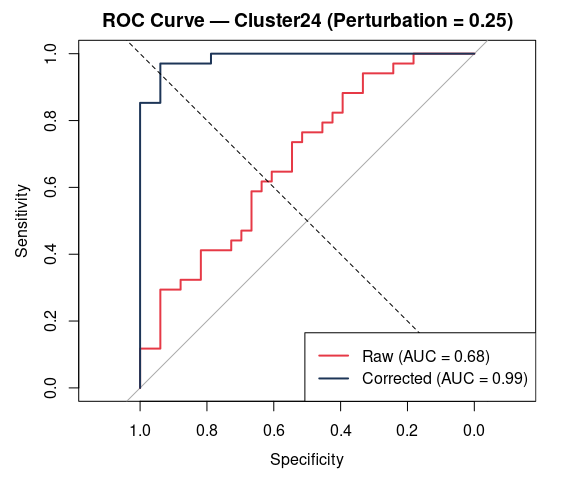

## 4.2 Latent Space Projection — Raw

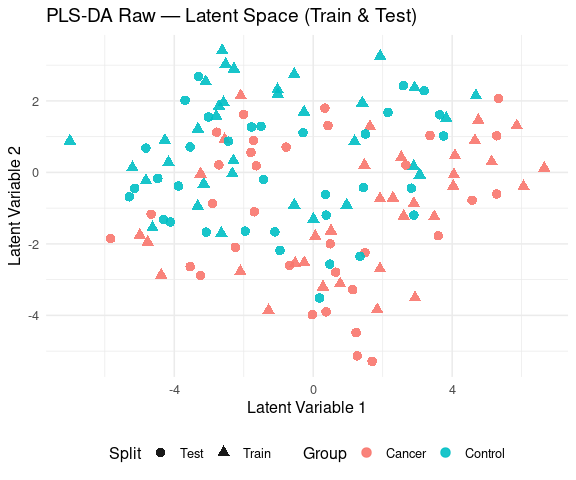

## 4.3 Latent Space Projection — Corrected

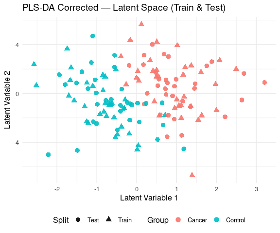

# 5. Run Simulation Across Clusters

In this step, we systematically evaluate how classification performance changes as the simulated “biomarker” effect increases, both before and after correction.

For each cluster and for a range of perturbation levels (from 0 to 1), the following procedure is applied:

1. A synthetic effect is introduced in the “Cancer” group for the selected cluster using `simulate_shift()`. The intensity increase is proportional to the cluster’s mean signal.
2. The resulting modified dataset is passed to `evaluate_auc()`, which computes the AUC of a PLS-DA classifier before and after correction.
3. This is repeated for all clusters and perturbation levels, producing a complete matrix of AUC values across different conditions.

To ensure reproducibility, a fixed seed (`seed = 42`) is used during each evaluation.  
This means that the random partitioning into training and test sets is **identical every time** the same simulation is run. As a result, differences in performance between the raw and corrected data can be attributed **solely to the correction itself**, not to randomness in the group split.

The results are stored as a long-format dataframe (`auc_df`), with columns: - `Cluster`: the cluster where the perturbation was applied - `Percent`: the perturbation level (from 0 to 1) - `Condition`: “Raw” or “Corrected” - `AUC`: the classification performance at that setting

This data is later used for visualizing performance trends across clusters.

```r
perturb_levels <- seq(0, 1, length.out = 20)
results_auc <- list()

for (cl in clusters) {
  cluster_auc <- purrr::map_dfr(perturb_levels, function(p) {
    df_mod <- simulate_shift(df, cl, p)
    aucs <- evaluate_auc(df_mod, meta, seed=42)
    tibble::tibble(Cluster = cl, Percent = p, Raw = aucs["Raw"], Corrected = aucs["Corrected"])
  })
  results_auc[[cl]] <- cluster_auc
}

auc_df <- dplyr::bind_rows(results_auc) %>%
  tidyr::pivot_longer(cols = c(Raw, Corrected), names_to = "Condition", values_to = "AUC")
```

## 5.1. Visualisation of AUC by Cluster

This section visualizes how classification performance evolves for each cluster as the simulated perturbation increases. For every cluster, we plot the AUC of the PLS-DA classifier as a function of the perturbation proportion, separately for the raw and corrected datasets.

Each plot shows two lines:

- **Raw** (uncorrected data)
- **Corrected** (after orthogonal projection)

These curves allow us to see how sensitive each cluster is to the simulated effect, and how much the correction improves detection for each level of perturbation. Clusters where the corrected AUC rises more steeply indicate a stronger benefit from the correction method.

Each plot is titled with the cluster ID (e.g., “Cluster16”) and uses a consistent y-axis range from 0.3 to 1.0 for comparability across clusters.

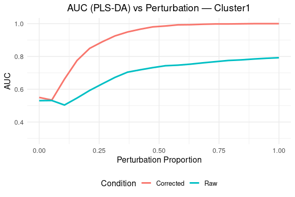

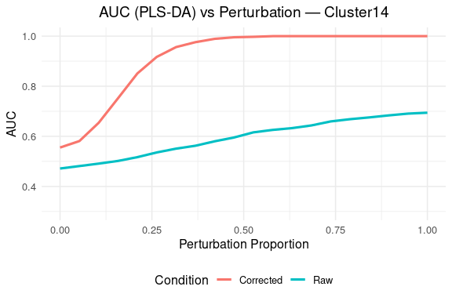

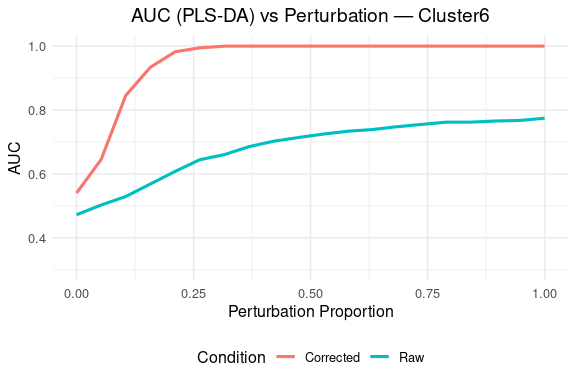

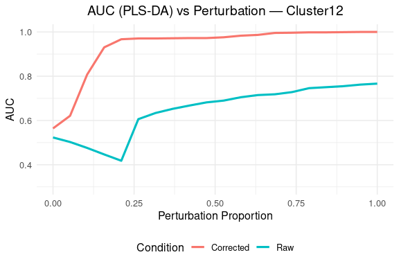

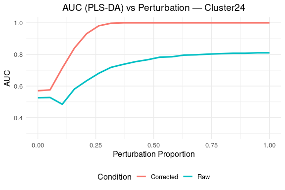

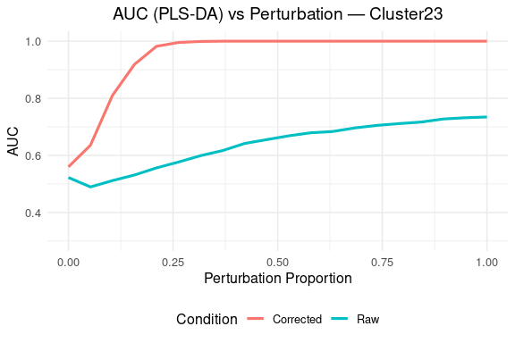

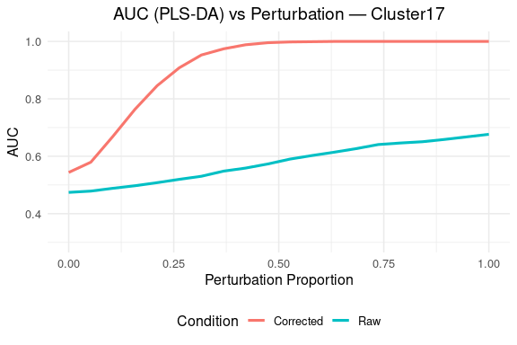

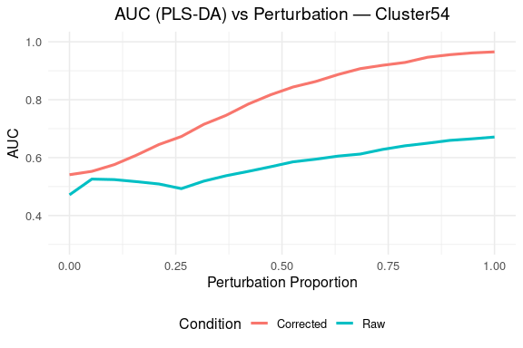

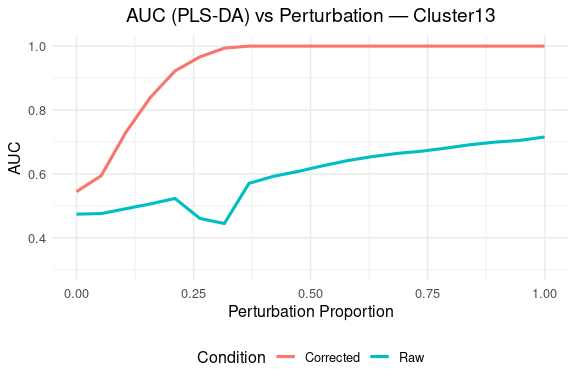

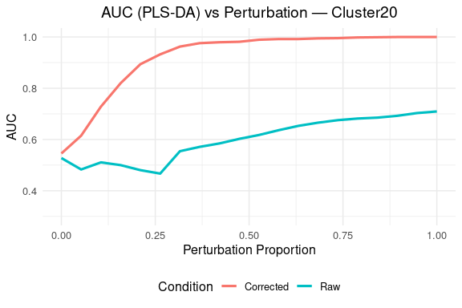

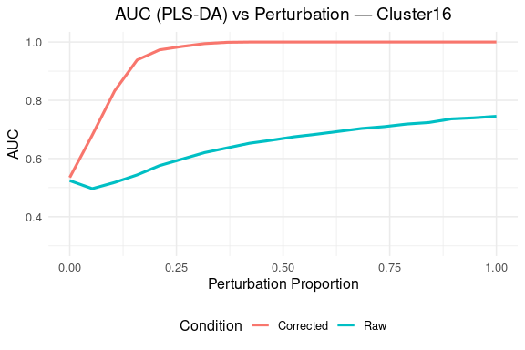

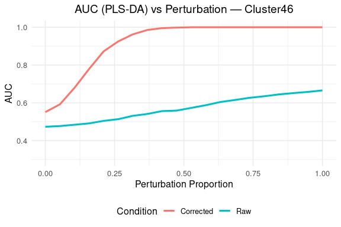

[19 more figures not shown]

# 6. Robustness Check

## 6.1. Repeated Random Assignments

To evaluate the stability of the observed AUC improvements, we repeat the group assignment multiple times with different random seeds. This controls for potential biases introduced by a single, lucky alignment between group labels and technical variables.

```r
set.seed(NULL)  # No seed fixation
n_repeats <- 200
target_cluster <- "Cluster14"

robust_results <- purrr::map_dfr(1:n_repeats, function(i) {
  df$Group <- sample(rep(c("Control", "Cancer"), length.out = nrow(df)))
  df_mod <- simulate_shift(df, cluster = target_cluster, perc = 0.25)
  aucs <- evaluate_auc(df_mod, meta)
  tibble::tibble(Iteration = i, Raw = aucs["Raw"], Corrected = aucs["Corrected"])
})
```

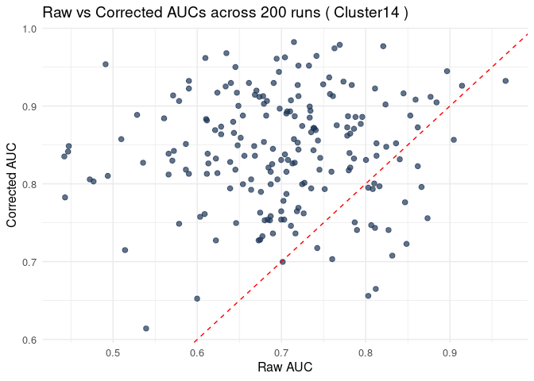

```r
ggplot(robust_results, aes(x = Raw, y = Corrected)) +
  geom_point(color = "#1D3557", alpha = 0.7, size = 2) +
  geom_abline(slope = 1, intercept = 0, linetype = "dashed", color = "red") +
  theme_minimal(base_size = 12) +
  labs(title = paste("Raw vs Corrected AUCs across 200 runs (", target_cluster, ")"),
       x = "Raw AUC", y = "Corrected AUC")
```

## 6.2. Global Validation Across Clusters and Perturbation Levels

To confirm that the improvement provided by othogonal correction is consistent across clusters and perturbation levels, we repeat the simulation for all clusters and multiple perturbation levels, with repeated random group assignments.

### Run Simulations

```r
perturb_seq <- seq(0, 1, by = 0.05)
n_repeats <- 10
results_global <- purrr::map_dfr(clusters, function(cl) {
  purrr::map_dfr(perturb_seq, function(p) {
    purrr::map_dfr(1:n_repeats, function(i) {
      df$Group <- sample(rep(c("Control", "Cancer"), length.out = nrow(df)))
      df_mod <- simulate_shift(df, cluster = cl, perc = p)
      aucs <- evaluate_auc(df_mod, meta)
      tibble::tibble(Cluster = cl, Perturbation = p, Rep = i,
                     Raw = aucs["Raw"], Corrected = aucs["Corrected"])
    })
  })
})
```

### Summary Statistics by Perturbation Level

To assess whether the correction provides a statistically significant improvement in classification performance, we perform a **one-sided paired Wilcoxon signed-rank test** at each perturbation level.

Each perturbation level (e.g., 0.05, 0.10, …) includes results from **multiple clusters**, and for each cluster the simulation is repeated **10 times** using different random group assignments. As a result, every perturbation level includes a large number of paired AUC values comparing the raw and corrected data under the exact same conditions (same cluster, perturbation level, and group assignment).

This non-parametric test compares the AUC values before and after correction for each simulation run, under the null hypothesis that the correction does **not** increase performance. The test is **paired**, meaning that each corrected AUC is compared to its corresponding raw AUC under the exact same conditions (same cluster, perturbation level, and group assignment), thereby controlling for random variation.

The Wilcoxon test is well suited for AUC values, which are bounded and may be non-normally distributed. However, due to the **large number of simulations per condition**, the test has very high statistical power. This means that **p-values are often extremely small**, even when the improvement is modest.

Therefore, **what truly matters in this context is not the p-value itself, but the size and consistency of the improvement**. For this reason, we report: - `mean_gain`: the average AUC increase after correction. - `prop_improved`: the proportion of simulations in which the corrected AUC is higher than the raw AUC.

Together, these metrics help quantify the practical benefit of the correction across a range of perturbation intensities.

```r
summary_global <- results_global %>%
  dplyr::group_by(Perturbation) %>%
  dplyr::summarise(
    p_value = wilcox.test(Corrected, Raw, paired = TRUE, alternative = "greater")$p.value,
    mean_gain = mean(Corrected - Raw),
    prop_improved = mean(Corrected > Raw)
  )

summary_global %>%
  kable(digits = 4, caption = "Summary of Improvement After Correction") %>%
  kable_styling(full_width = FALSE, position = "center", bootstrap_options = c("striped", "hover"))
```

Summary of Improvement After Correction

| Perturbation | p_value | mean_gain | prop_improved |
| --- | --- | --- | --- |
| 0.00 | 0.5032 | 0.0008 | 0.4935 |
| 0.05 | 0.0008 | 0.0162 | 0.5742 |
| 0.10 | 0.0000 | 0.0616 | 0.7032 |
| 0.15 | 0.0000 | 0.1021 | 0.7903 |
| 0.20 | 0.0000 | 0.1062 | 0.7806 |
| 0.25 | 0.0000 | 0.1197 | 0.8290 |
| 0.30 | 0.0000 | 0.1106 | 0.7548 |
| 0.35 | 0.0000 | 0.1086 | 0.7806 |
| 0.40 | 0.0000 | 0.0881 | 0.7581 |
| 0.45 | 0.0000 | 0.0846 | 0.8032 |
| 0.50 | 0.0000 | 0.0661 | 0.6968 |
| 0.55 | 0.0000 | 0.0618 | 0.7097 |
| 0.60 | 0.0000 | 0.0532 | 0.6548 |
| 0.65 | 0.0000 | 0.0469 | 0.6387 |
| 0.70 | 0.0000 | 0.0439 | 0.6161 |
| 0.75 | 0.0000 | 0.0304 | 0.5548 |
| 0.80 | 0.0000 | 0.0344 | 0.5806 |
| 0.85 | 0.0000 | 0.0318 | 0.6258 |
| 0.90 | 0.0000 | 0.0239 | 0.5839 |
| 0.95 | 0.0000 | 0.0153 | 0.5484 |
| 1.00 | 0.0000 | 0.0286 | 0.5581 |